# Прохождении 3 этапа внешних курсов

Продвинутые темы

Киселева Елизавета Александровна

Российский университет дружбы народов, Москва, Россия

17.05.25

# Информация

## Докладчик

- Киселева Елизавета Александровна, НКАбд-02-24
- Студентка факультета физико-математических и естественных наук
- Российский университет дружбы народов
- 1132246735
- https://github.com/liza11223/site-project.git
- https://liza11223.github.io/site-project/
- https://github.com/liza11223/study_2024-2025_os-intro.git

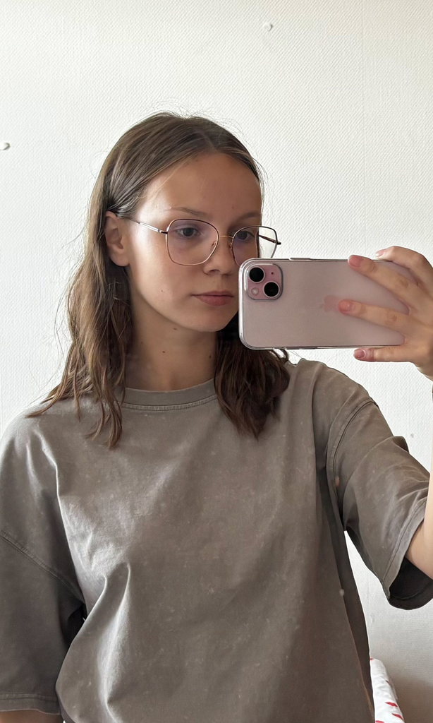

## Цель работы

Ознакомиться с функционалом операционной системы Linux.

## Задание

Просмотреть видео и на основе полученной информации пройти тестовые задания.

## Теоретическое введение

Линукс - в части случаев GNU/Linux — семейство Unix-подобных операционных систем на базе ядра Linux, включающих тот или иной набор утилит и программ проекта GNU, и, возможно, другие компоненты. Как и ядро Linux, системы на его основе, как правило, создаются и распространяются в соответствии с моделью разработки свободного и открытого программного обеспечения. Linux-системы распространяются в основном бесплатно в виде различных дистрибутивов — в форме, готовой для установки и удобной для сопровождения и обновлений, — и имеющих свой набор системных и прикладных компонентов, как свободных, так и проприетарных.

# Выполнение лабораторной работы

## Этап 3:

[figure not shown]

Задание 1

Стоит упомянуть, что у редактора vim есть туториал, который позволяет разобраться с командами, необходимыми для стандартной работы. За выход из редактора отвечают следующие команды:

[figure not shown]

Задание 2

`Strange_ TEXT is_here. 2=2 YES!`

Точка считается “маленьким словом”, так что всего их 9: `Strange_`, `is_here`, `.`, `2`, `=`, `2`, `!` и `два лишних пробела`.

[figure not shown]

Задание 3

`d2wwifour four <<Esc>>`

`d2wwywPp`

`d2w$$bifour four <<Esc>>`

[figure not shown]

Задание 4

Поиск и замена в редакторе работают по следующей схеме:

`:{пределы}s/{что заменяем}/{на что заменяем}/{опции}`

Для замены во всем файле можно использовать символ %.

[figure not shown]

Задание 5

Команда $ — в конец текущей строки, W - до пробела вправо - то есть, перемещение. Нажать Esc достаточно один раз, но да ладно. Надпись visual - горит. d — используется совместно с командами перемещения. Удаляет символы с текущего положения курсора до положения после ввода команды перемещения. yy (также Y) — копирование текущей строки в буфер;

[figure not shown]

Задание 6

Только из набора С потому что у каждой оболочки свой буфер, который при выходе из нее буде записываться в файл истории.

[figure not shown]

Задание 7

`/home/bi/file1.txt` - потому что именно в этой директории мы создаем новый файл, а уже после его создания мы переходим в другую папку.

[figure not shown]

Задание 8

Имя не может начинаться с цифры, содержать специальные символы или пробелы.

[figure not shown]

Задание 9

`$ echo опции строка` `var1=$1` - обозначение переменных `var2=$2` `echo "Arguments are: \$1=$var1 \$2=$var2"` - строка печати.

[figure not shown]

Задание 10

- $0 - имя скрипта
- $# - вернет количество аргументов
- -ge - больше или равно
- -n - не пустая строка.

[figure not shown]

Задание 11

- -lt, (<) - меньше
- -gt - больше
- -eq - равно

[figure not shown]

Задание 12

1. Задаю общую часть в каждом выводе - слово “student”: v=student
2. Выполняем команды для разных аргументов.
3. res - это результат для вывода
4. echo “$res” - вывести результат

[figure not shown]

Задание 13

[figure not shown]

Задание 14

[figure not shown]

Задание 14

[figure not shown]

Задание 15

1. a = $a
2. a += b это то же самое, что и a = a + b, но с символами “+=” != “=+”
3. если выражение не в скобках, но с пробелами - работать не будет. (let a=a+b - сработает; let a = a + b - нет)

[figure not shown]

Задание 16

Выведет путь до директории, в которую мы перешли, так как “`pwd`” - это команда

[figure not shown]

Задание 16_2

`programm` выполняет стандартный вывод в терминал (если это принцип работы программы). И нам нужно настроить вывод в файл.

[figure not shown]

Задание 17

Первая переменная локальная, и это просто пустая строка, вторая переменная - это сумма арифметической прогрессии от 1 до 10, равна 55, но при умножении на 2 даст 110.

[figure not shown]

Задание 18

[figure not shown]

Задание 18

Алгоритм нахождения НОД делением

[figure not shown]

Задание 19

[figure not shown]

Задание 19

Калькулятор выглядит обычно - мы вводим два числа, пишем, что с ними надо сделать, и потом, учитывая случаи ошибок, выводим результат.

[figure not shown]

Задание 20

-iname ищет без учета регистра, а -name в точности как в запросе. Звездочка стоит после слова - это значит после слова может быть сколько угодно символов.

[figure not shown]

Задание 21

find [path] [expression]

[figure not shown]

Задание 22

[figure not shown]

Задание 23

Из описания man: Print NUM lines of trailing context after/before matching lines “matching lines” - множественное число, строки в которых нашлось совпадение

[figure not shown]

Задание 24

[figure not shown]

Задание 24